# Visualization Analysis (Team-Level)

#### Rebounds

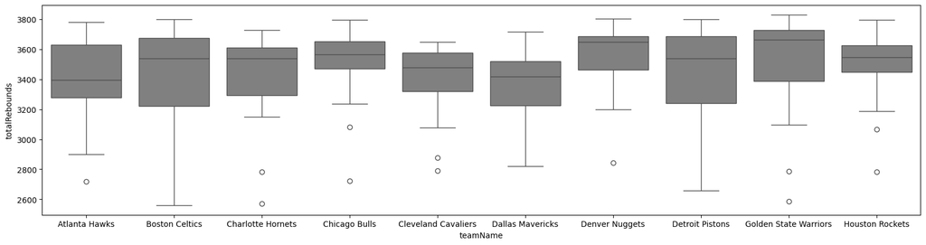

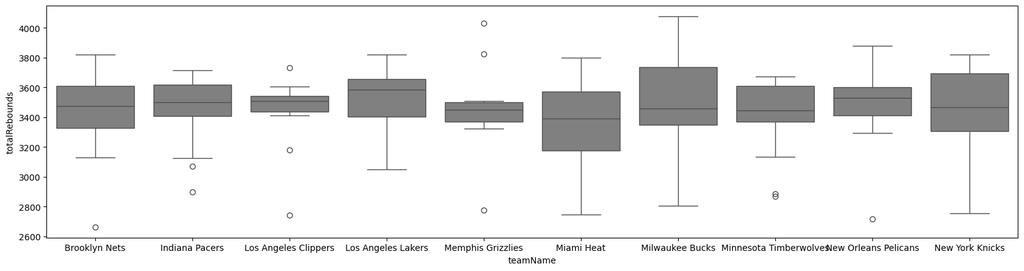

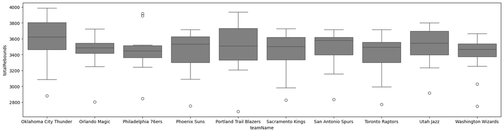

```python
plot_boxplot("totalRebounds",regular_season_team_summary_stats_1)
plot_boxplot("totalRebounds",regular_season_team_summary_stats_2)
plot_boxplot("totalRebounds",regular_season_team_summary_stats_3)
```

For rebounds, Denver Nuggets was selected as the higher-performing team and Miami Heat as the lower-performing team.

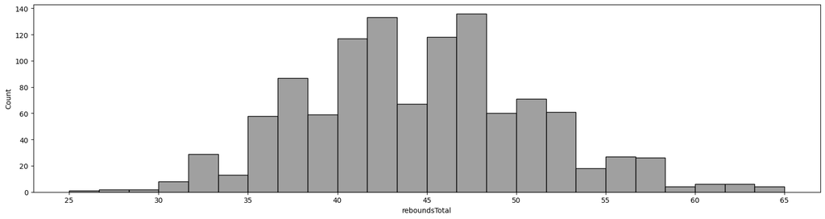

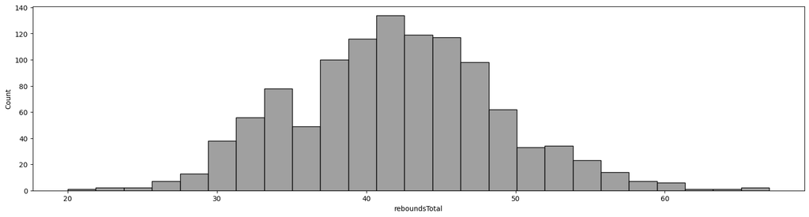

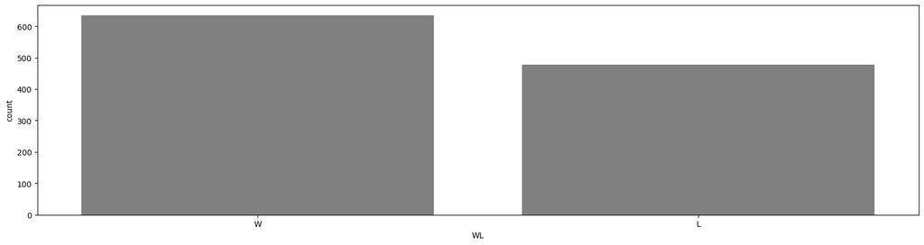

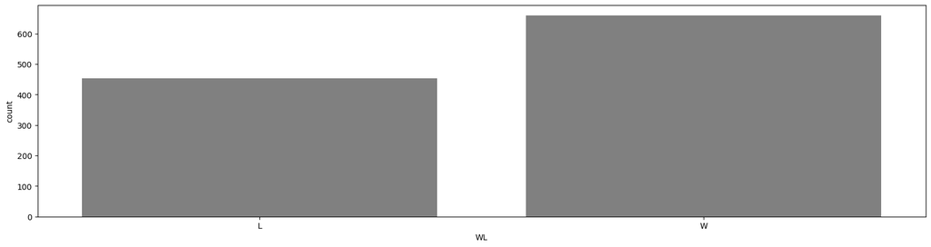

```python
den_regular_season_totals = regular_season_totals[regular_season_totals["teamName"] == "Denver Nuggets"]
mia_regular_season_totals = regular_season_totals[regular_season_totals["teamName"] == "Miami Heat"]

plot_histogram("reboundsTotal",den_regular_season_totals)
plot_histogram("reboundsTotal",mia_regular_season_totals)
plot_barchart("WL",den_regular_season_totals)
plot_barchart("WL",mia_regular_season_totals)
```

As observed when analysing three pointers made, Denver Nuggets do not have more wins than Miami Heat despite having more rebounds.

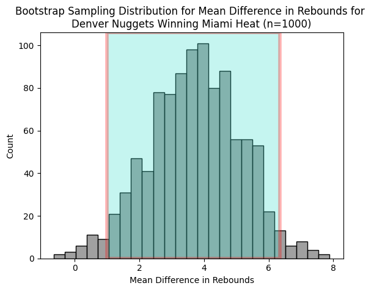

```
[0.9970588235294119, 6.354411764705881]
```

```python
np.random.seed(100)

combined_games_regular_season["diffRebounds"] = combined_games_regular_season["reboundsTotal_x"] - combined_games_regular_season["reboundsTotal_y"]

combined_games_play_offs["diffRebounds"] = combined_games_play_offs["reboundsTotal_x"] - combined_games_play_offs["reboundsTotal_y"]


den_mia_games = combined_games_regular_season[(combined_games_regular_season["teamName_x"] == "Denver Nuggets") & (combined_games_regular_season["teamName_y"] == "Miami Heat")]

den_mia_rebounds_bootstrap_distribution = bootstrap_distribution("diffRebounds",den_mia_games)

den_mia_rebounds_percentile_confidence_interval = confidence_interval(den_mia_rebounds_bootstrap_distribution)

plt.xlabel("Mean Difference in Rebounds")
plt.title("Bootstrap Sampling Distribution for Mean Difference in Rebounds for \nDenver Nuggets Winning Miami Heat (n=1000)")
den_mia_rebounds_confidence_interval = visualize_confidence_interval(den_mia_rebounds_bootstrap_distribution,den_mia_rebounds_percentile_confidence_interval)

den_mia_rebounds_percentile_confidence_interval
```

The confidence interval is once again relatively wide, likely to be due to the limited sample size of only 17 games in which the Denver Nuggets beat the Miami Heat.

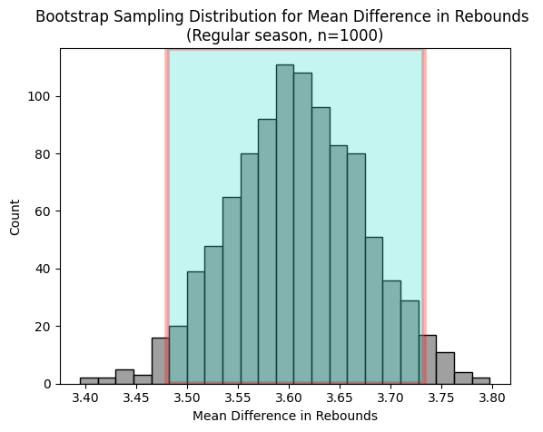

```
[3.480279745467643, 3.7330246728298713]
```

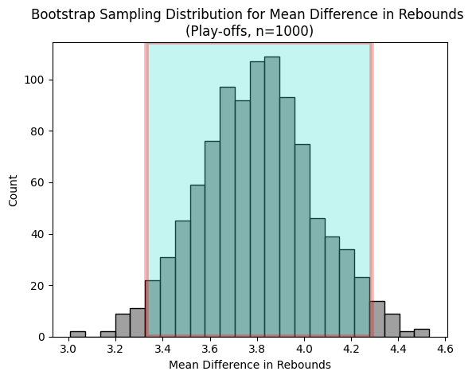

```
[3.329093931837074, 4.289318370739817]
```

```python
np.random.seed(100)

rebounds_regular_season_bootstrap_distribution = bootstrap_distribution("diffRebounds",combined_games_regular_season)

rebounds_regular_season_percentile_confidence_interval = confidence_interval(rebounds_regular_season_bootstrap_distribution)

plt.xlabel("Mean Difference in Rebounds")
plt.title("Bootstrap Sampling Distribution for Mean Difference in Rebounds \n(Regular season, n=1000)")
rebounds_regular_season_confidence_interval = visualize_confidence_interval(rebounds_regular_season_bootstrap_distribution,rebounds_regular_season_percentile_confidence_interval)
print(rebounds_regular_season_percentile_confidence_interval)

rebounds_play_offs_bootstrap_distribution = bootstrap_distribution("diffRebounds",combined_games_play_offs)

rebounds_play_offs_percentile_confidence_interval = confidence_interval(rebounds_play_offs_bootstrap_distribution)

plt.xlabel("Mean Difference in Rebounds")
plt.title("Bootstrap Sampling Distribution for Mean Difference in Rebounds \n(Play-offs, n=1000)")
rebounds_play_offs_confidence_interval = visualize_confidence_interval(rebounds_play_offs_bootstrap_distribution,rebounds_play_offs_percentile_confidence_interval)
print(rebounds_play_offs_percentile_confidence_interval)
```

As previously noted, the confidence interval for both samples is narrower due to the large sample sizes. Given that the lower bounds are approximately above a mean difference of 3 rebounds, the data support the conclusion that securing more rebounds is positively associated with winning. As usual, using the play-offs sample results in a wider interval than using the regular season sample as the sample size is smaller, which results in less precision.

#### Assists

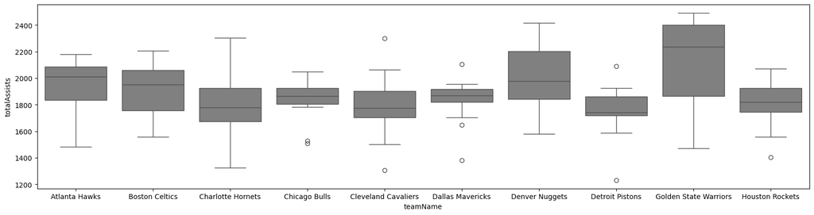

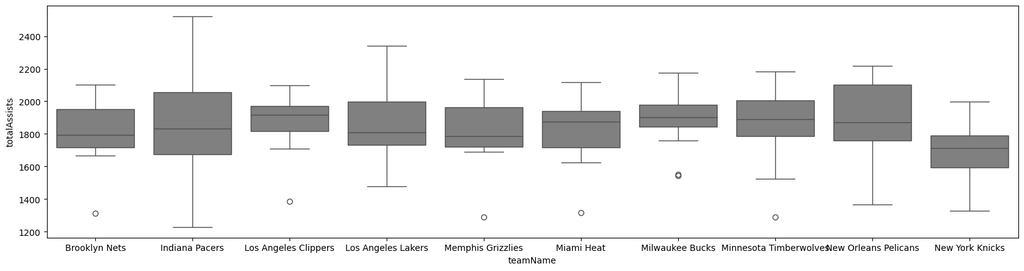

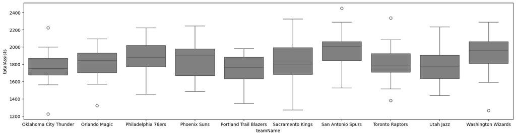

```python
plot_boxplot("totalAssists",regular_season_team_summary_stats_1)
plot_boxplot("totalAssists",regular_season_team_summary_stats_2)
plot_boxplot("totalAssists",regular_season_team_summary_stats_3)
```

The Golden State Warriors was selected as the higher-peforming team for assists, while the New York Knicks was selected as the lower-performing team.

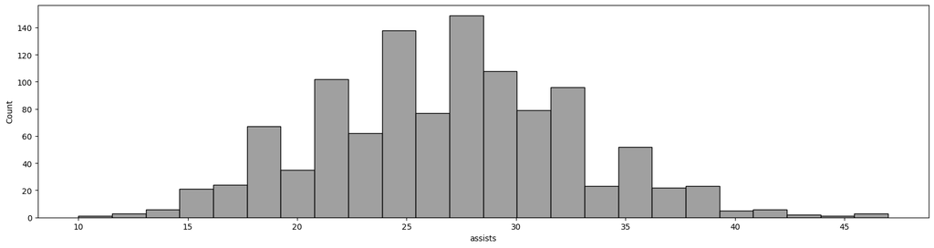

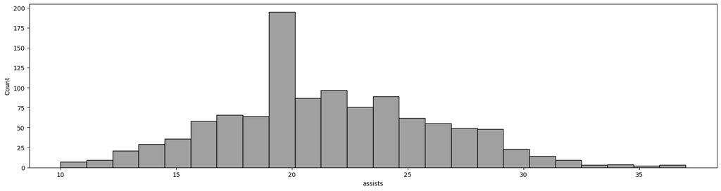

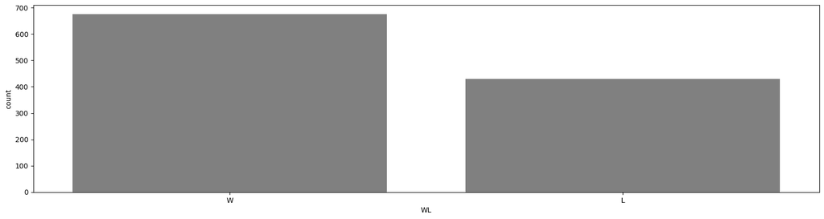

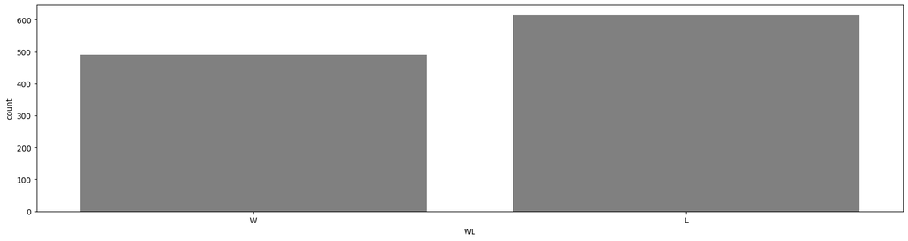

```python
gsw_regular_season_totals = regular_season_totals[regular_season_totals["teamName"] == "Golden State Warriors"]
nyk_regular_season_totals = regular_season_totals[regular_season_totals["teamName"] == "New York Knicks"]

plot_histogram("assists",gsw_regular_season_totals)
plot_histogram("assists",nyk_regular_season_totals)
plot_barchart("WL",gsw_regular_season_totals)
plot_barchart("WL",nyk_regular_season_totals)
```

There is a clear sharp contrast between the assists each team makes and also the number of games they won. The Golden State Warriors have more assists while having more wins, while the New York Knicks have less assists and less wins.

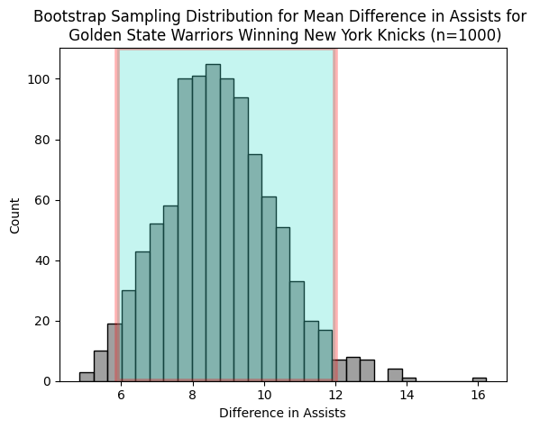

```
[5.888888888888889, 12.001388888888888]
```

```python
np.random.seed(100)

combined_games_regular_season["diffAssists"] = combined_games_regular_season["assists_x"] - combined_games_regular_season["assists_y"]
combined_games_play_offs["diffAssists"] = combined_games_play_offs["assists_x"] - combined_games_play_offs["assists_y"]

gsw_nyk_games = combined_games_regular_season[(combined_games_regular_season["teamName_x"]=="Golden State Warriors") & (combined_games_regular_season["teamName_y"]=="New York Knicks")]

gsw_nyk_assists_bootstrap_distribution = bootstrap_distribution("diffAssists",gsw_nyk_games)

gsw_nyk_assists_percentile_confidence_interval = confidence_interval(gsw_nyk_assists_bootstrap_distribution)

plt.xlabel("Difference in Assists")
plt.title("Bootstrap Sampling Distribution for Mean Difference in Assists for \n Golden State Warriors Winning New York Knicks (n=1000)")
gsw_nyk_assists_confidence_interval = visualize_confidence_interval(gsw_nyk_assists_bootstrap_distribution,gsw_nyk_assists_percentile_confidence_interval)
print(gsw_nyk_assists_percentile_confidence_interval)
```

The confidence interval exhibits the largest difference observed thus far in this project, with a lower bound of approximately 5.89 assists.

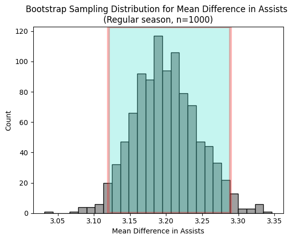

```
[3.120283047184536, 3.2888867210949693]
```

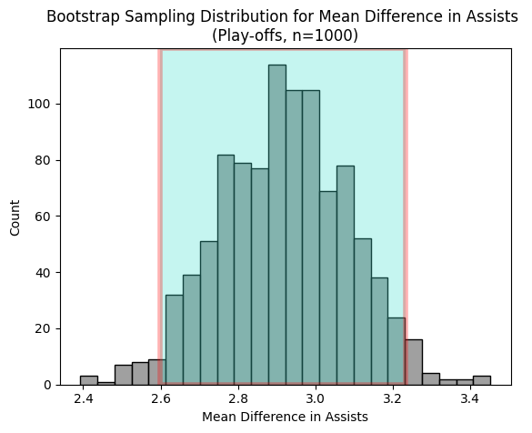

```
[2.599334995843724, 3.2319825436408975]
```

```python
np.random.seed(100)

assists_regular_season_bootstrap_distribution = bootstrap_distribution("diffAssists",combined_games_regular_season)

assists_regular_season_percentile_confidence_interval = confidence_interval(assists_regular_season_bootstrap_distribution)

plt.xlabel("Mean Difference in Assists")
plt.title("Bootstrap Sampling Distribution for Mean Difference in Assists \n(Regular season, n=1000)")
assists_regular_season_confidence_interval = visualize_confidence_interval(assists_regular_season_bootstrap_distribution,assists_regular_season_percentile_confidence_interval)
print(assists_regular_season_percentile_confidence_interval)

assists_play_offs_bootstrap_distribution = bootstrap_distribution("diffAssists",combined_games_play_offs)

assists_play_offs_percentile_confidence_interval = confidence_interval(assists_play_offs_bootstrap_distribution)

plt.xlabel("Mean Difference in Assists")
plt.title("Bootstrap Sampling Distribution for Mean Difference in Assists \n(Play-offs, n=1000)")
assists_play_offs_confidence_interval = visualize_confidence_interval(assists_play_offs_bootstrap_distribution,assists_play_offs_percentile_confidence_interval)
print(assists_play_offs_percentile_confidence_interval)
```

The confidence intervals align with the results observed for the mean differences in assists when Golden State Warriors beat New York Knicks, with lower bounds of above approximately 2.5 assists. This again suggests that recording more assists has a positive relationship with winning games.

#### Steals

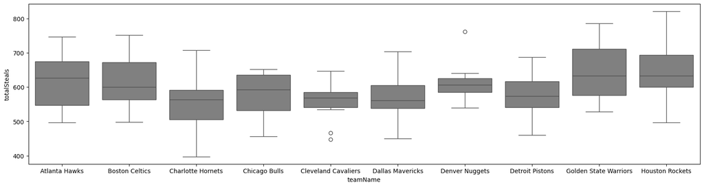

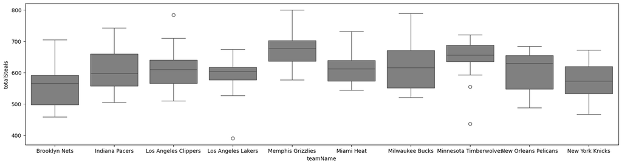

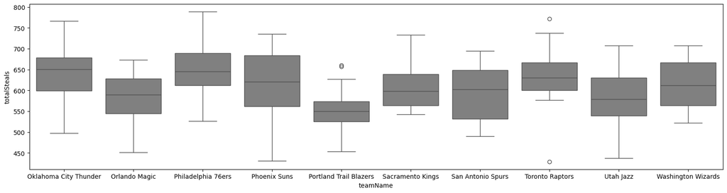

```python
plot_boxplot("totalSteals",regular_season_team_summary_stats_1)
plot_boxplot("totalSteals",regular_season_team_summary_stats_2)
plot_boxplot("totalSteals",regular_season_team_summary_stats_3)
```

Memphis Grizzlies perform better in steals than Portland Trail Blazers while having more wins.

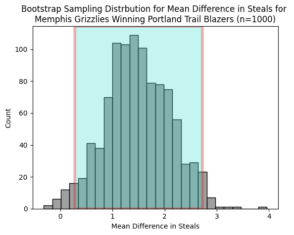

```
[0.2790000000000001, 2.720999999999999]
```

```python
np.random.seed(100)

combined_games_regular_season["diffSteals"] = combined_games_regular_season["steals_x"] - combined_games_regular_season["steals_y"]
combined_games_play_offs["diffSteals"] = combined_games_play_offs["steals_x"] - combined_games_play_offs["steals_y"]

mem_por_games = combined_games_regular_season[(combined_games_regular_season["teamName_x"]=="Memphis Grizzlies") & (combined_games_regular_season["teamName_y"]=="Portland Trail Blazers")]

mem_por_steals_bootstrap_distribution = bootstrap_distribution("diffSteals",mem_por_games)

mem_por_steals_percentile_confidence_interval = confidence_interval(mem_por_steals_bootstrap_distribution)

plt.xlabel("Mean Difference in Steals")
plt.title("Bootstrap Sampling Distrbution for Mean Difference in Steals for \nMemphis Grizzlies Winning Portland Trail Blazers (n=1000)")
mem_por_steals_confidence_interval = visualize_confidence_interval(mem_por_steals_bootstrap_distribution,mem_por_steals_percentile_confidence_interval)
print(mem_por_steals_percentile_confidence_interval)
```

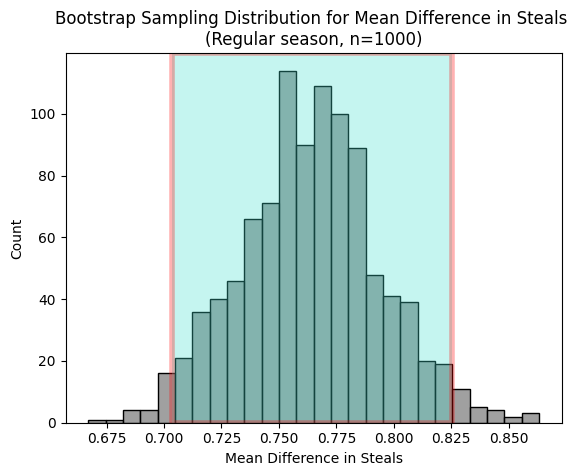

```
[0.7036844158962661, 0.8254397286589026]
```

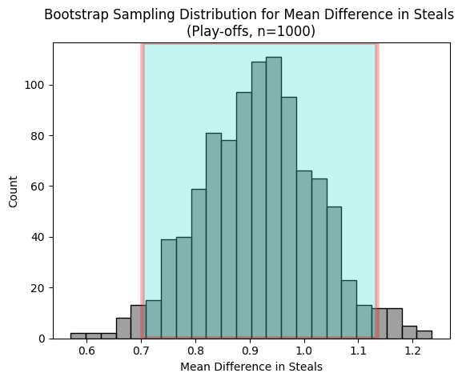

```
[0.7024106400665004, 1.1355153782211138]
```

```python
np.random.seed(100)

steals_regular_season_bootstrap_distribution = bootstrap_distribution("diffSteals",combined_games_regular_season)

steals_regular_season_percentile_confidence_interval = confidence_interval(steals_regular_season_bootstrap_distribution)

plt.xlabel("Mean Difference in Steals")
plt.title("Bootstrap Sampling Distribution for Mean Difference in Steals \n(Regular season, n=1000)")
steals_regular_season_confidence_interval = visualize_confidence_interval(steals_regular_season_bootstrap_distribution,steals_regular_season_percentile_confidence_interval)
print(steals_regular_season_percentile_confidence_interval)

steals_play_offs_bootstrap_distribution = bootstrap_distribution("diffSteals",combined_games_play_offs)

steals_play_offs_percentile_confidence_interval = confidence_interval(steals_play_offs_bootstrap_distribution)

plt.xlabel("Mean Difference in Steals")
plt.title("Bootstrap Sampling Distribution for Mean Difference in Steals \n(Play-offs, n=1000)")
steals_play_offs_confidence_interval = visualize_confidence_interval(steals_play_offs_bootstrap_distribution,steals_play_offs_percentile_confidence_interval)
print(steals_play_offs_percentile_confidence_interval)
```

Because both 95% confidence intervals tends to range values below 1, it is 95% confident that the true mean difference in steals between winning teams and losing teams is minimal. This aligns well with the results when observing instances where the Memphis Grizzlies beat the Portland Trail Blazers. Although the play-offs sample resulted in a 95% confidence interval with an upper bound of approximately 1.13 steals, most of the values in the interval are still below 1. Additionally, it is less precise than the confidnece interval constructed from using the regular season sample.

#### Blocks

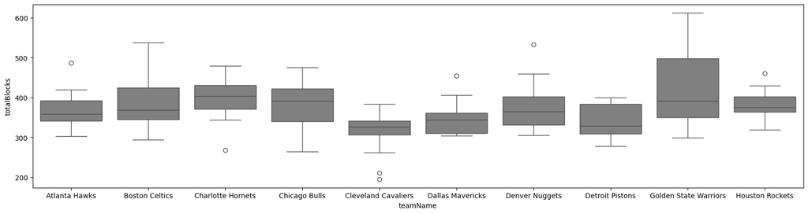

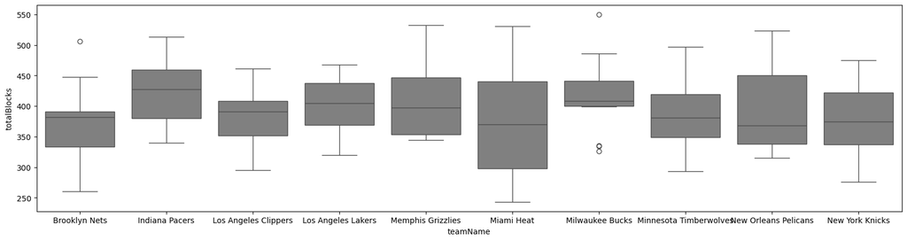

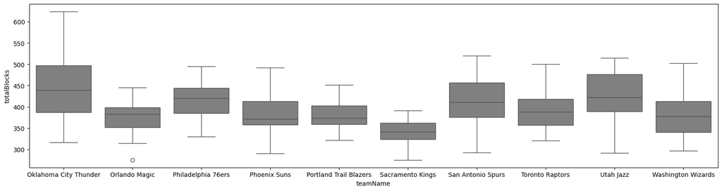

```python
plot_boxplot("totalBlocks",regular_season_team_summary_stats_1)
plot_boxplot("totalBlocks",regular_season_team_summary_stats_2)
plot_boxplot("totalBlocks",regular_season_team_summary_stats_3)
```

For blocks, Oklahoma City Thunder was selected as the higher-performing team and Cleveland Cavaliers was selected as the lower performing team.

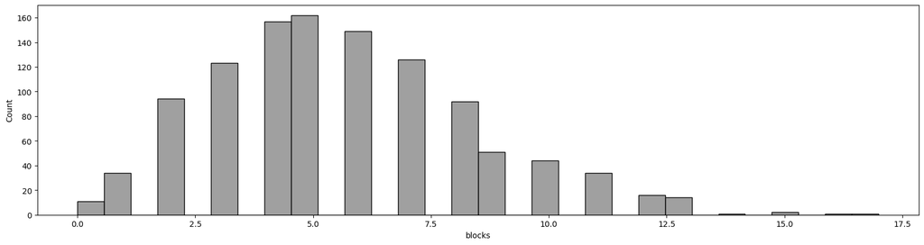

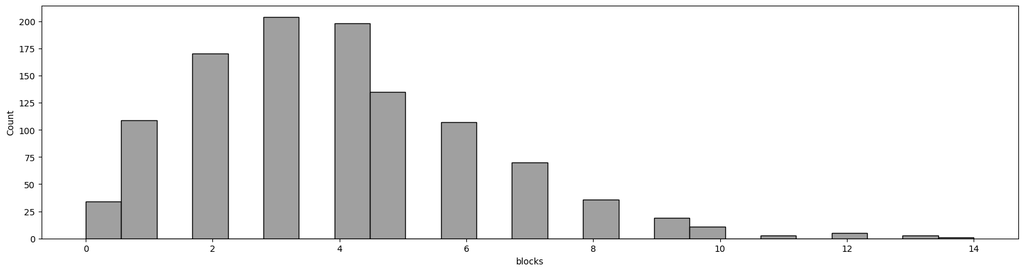

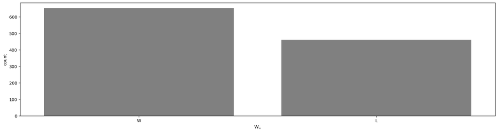

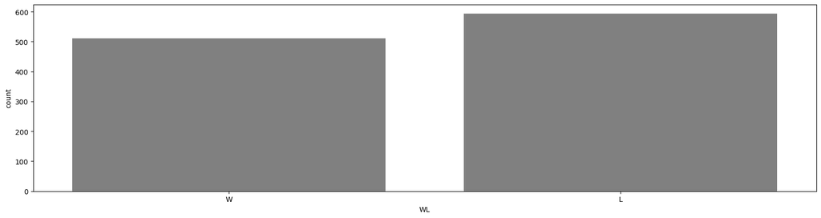

```python
okc_regular_season_totals = regular_season_totals[regular_season_totals["teamName"]=="Oklahoma City Thunder"]
cle_regular_season_totals = regular_season_totals[regular_season_totals["teamName"]=="Cleveland Cavaliers"]

plot_histogram("blocks",okc_regular_season_totals)
plot_histogram("blocks",cle_regular_season_totals)
plot_barchart("WL",okc_regular_season_totals)
plot_barchart("WL",cle_regular_season_totals)
```

The results produce a staunch difference between the two teams once again. Oklahoma City Thunder tends to have more blocks while winning more than Cleveland Cavaliers.

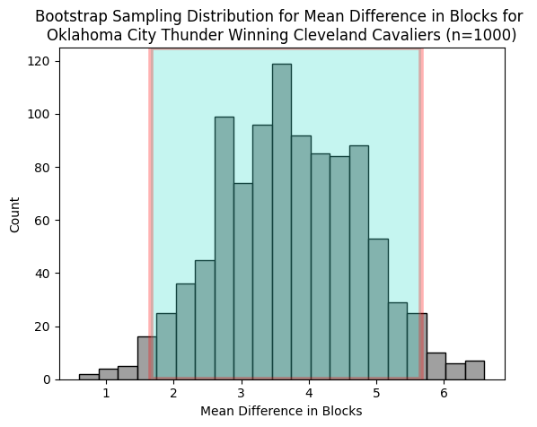

```
[1.6666666666666667, 5.668333333333332]
```

```python
np.random.seed(100)

combined_games_regular_season["diffBlocks"] = combined_games_regular_season["blocks_x"] - combined_games_regular_season["blocks_y"]
combined_games_play_offs["diffBlocks"] = combined_games_play_offs["blocks_x"] - combined_games_play_offs["blocks_y"]

okc_cle_games = combined_games_regular_season[(combined_games_regular_season["teamName_x"] == "Oklahoma City Thunder") & (combined_games_regular_season["teamName_y"] == "Cleveland Cavaliers")]

okc_cle_blocks_bootstrap_distribution = bootstrap_distribution("diffBlocks",okc_cle_games)

okc_cle_blocks_percentile_confidence_interval = confidence_interval(okc_cle_blocks_bootstrap_distribution)


plt.xlabel("Mean Difference in Blocks")
plt.title("Bootstrap Sampling Distribution for Mean Difference in Blocks for \nOklahoma City Thunder Winning Cleveland Cavaliers (n=1000)")
okc_cle_blocks_confidence_interval = visualize_confidence_interval(okc_cle_blocks_bootstrap_distribution,okc_cle_blocks_percentile_confidence_interval)
print(okc_cle_blocks_percentile_confidence_interval)
```

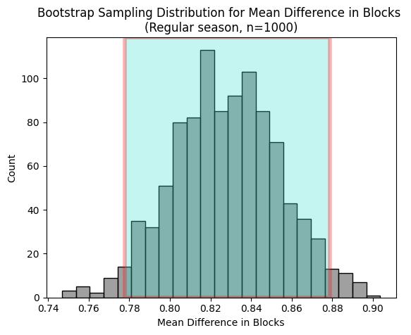

```
[0.7778079601392724, 0.8788299915956297]
```

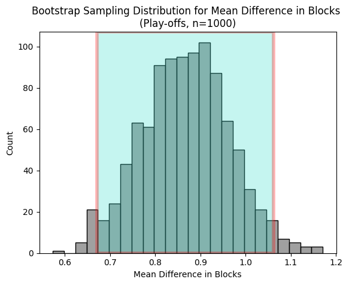

```
[0.6707605985037406, 1.0623649210307564]
```

```python
np.random.seed(100)

blocks_regular_season_bootstrap_distribution = bootstrap_distribution("diffBlocks",combined_games_regular_season)

blocks_regular_season_percentile_confidence_interval = confidence_interval(blocks_regular_season_bootstrap_distribution)

plt.xlabel("Mean Difference in Blocks")
plt.title("Bootstrap Sampling Distribution for Mean Difference in Blocks \n(Regular season, n=1000)")
blocks_regular_season_confidence_interval = visualize_confidence_interval(blocks_regular_season_bootstrap_distribution,blocks_regular_season_percentile_confidence_interval)
print(blocks_regular_season_percentile_confidence_interval)

blocks_play_offs_bootstrap_distribution = bootstrap_distribution("diffBlocks",combined_games_play_offs)

blocks_play_offs_percentile_confidence_interval = confidence_interval(blocks_play_offs_bootstrap_distribution)

plt.xlabel("Mean Difference in Blocks")
plt.title("Bootstrap Sampling Distribution for Mean Difference in Blocks \n(Play-offs, n=1000)")
blocks_play_offs_confidence_interval = visualize_confidence_interval(blocks_play_offs_bootstrap_distribution,blocks_play_offs_percentile_confidence_interval)
print(blocks_play_offs_percentile_confidence_interval)
```

#### Fouls

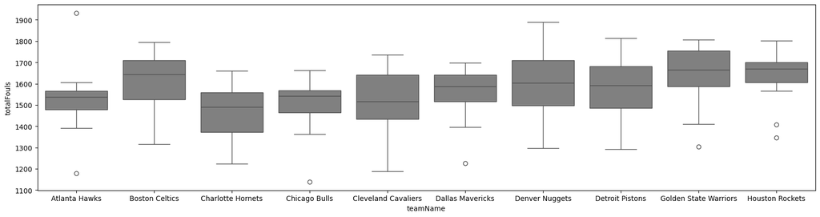

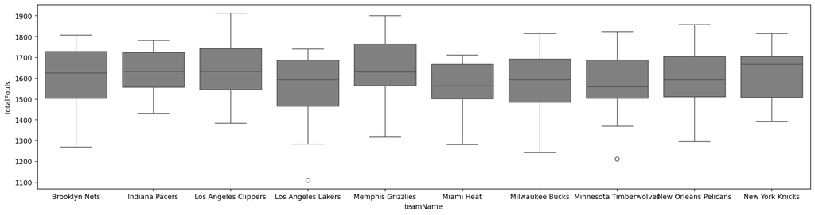

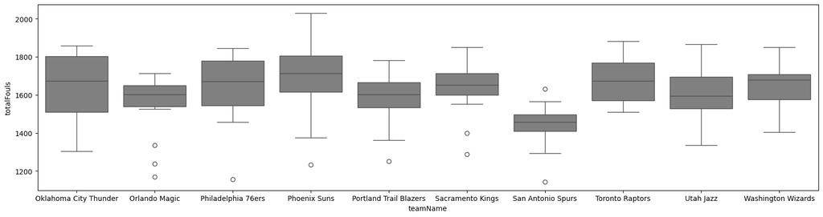

```python
plot_boxplot("totalFouls",regular_season_team_summary_stats_1)
plot_boxplot("totalFouls",regular_season_team_summary_stats_2)
plot_boxplot("totalFouls",regular_season_team_summary_stats_3)
```

For fouls, Phoenix Suns was selected as the higher-performing team and San Antonio Spurs was selected as the lower-performing team

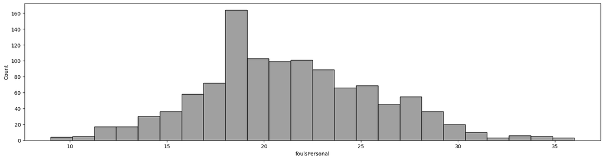

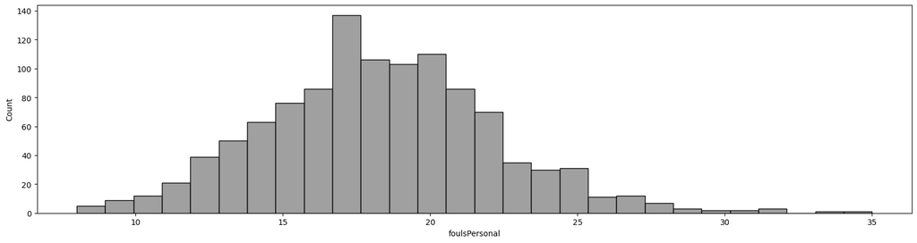

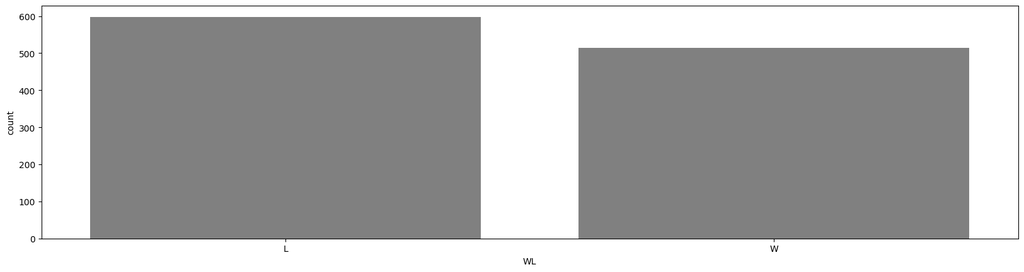

```python
phx_regular_season_totals = regular_season_totals[regular_season_totals["teamName"]=="Phoenix Suns"]

plot_histogram("foulsPersonal",phx_regular_season_totals)
plot_histogram("foulsPersonal",sas_regular_season_totals)
plot_barchart("WL",phx_regular_season_totals)
plot_barchart("WL",sas_regular_season_totals)
```

[output not shown]

The Phoenix Suns tend to have more fouls while having fewer wins, and the San Antonio Spurs tend to have fewer fouls with more wins. Unlike the other variables examined, it is important to note that in basketball, fouls are negative metrics of a team or player, so having fewer fouls is considered favourable. Therefore, for the next comparison, games where the San Antonio Spurs beat the Phoenix Suns will be focused on.

[figure not shown]

```
[-3.6470588235294117, -0.8235294117647058]
```

```python
np.random.seed(100)

combined_games_regular_season["diffFouls"] = combined_games_regular_season["foulsPersonal_x"] - combined_games_regular_season["foulsPersonal_y"]
combined_games_play_offs["diffFouls"] = combined_games_play_offs["foulsPersonal_x"] - combined_games_play_offs["foulsPersonal_y"]

phx_sas_games = combined_games_regular_season[(combined_games_regular_season["teamName_x"] == "San Antonio Spurs") & (combined_games_regular_season["teamName_y"] == "Phoenix Suns")]

phx_sas_blocks_bootstrap_distribution = bootstrap_distribution("diffFouls",phx_sas_games)

phx_sas_blocks_percentile_confidence_interval = confidence_interval(phx_sas_blocks_bootstrap_distribution)

plt.xlabel("Mean Difference in Fouls")
plt.title("Bootstrap Sampling Distribution for Mean Difference in Fouls for \nPhoenix Suns Winning San Antonio Spurs (n=1000)")
phx_sas_blocks_confidence_interval = visualize_confidence_interval(phx_sas_blocks_bootstrap_distribution,phx_sas_blocks_percentile_confidence_interval)
print(phx_sas_blocks_percentile_confidence_interval)
```

It is observed that the confidence interval includes negative values, indicating that, on average, the San Antonio Spurs commit fewer fouls than the Phoenix Suns. As previously noted, committing fewer fouls is a positive metric in basketball, suggesting that having fewer fouls is positively associated with winning.

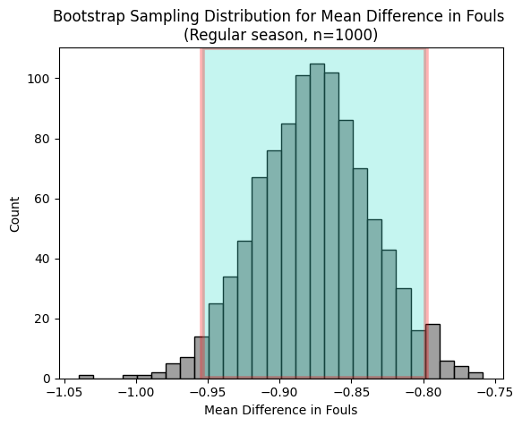

```
[-0.9539620602713411, -0.7976197622763838]
```

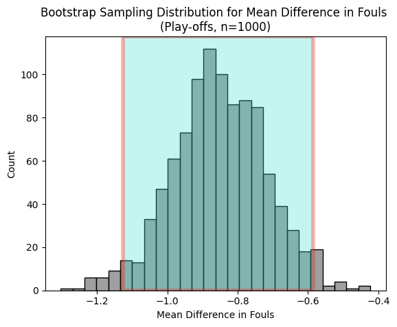

```
[-1.1264546965918538, -0.5860141313383209]
```

```python
np.random.seed(100)

fouls_regular_season_bootstrap_distribution = bootstrap_distribution("diffFouls",combined_games_regular_season)

fouls_regular_season_percentile_confidence_interval = confidence_interval(fouls_regular_season_bootstrap_distribution)

plt.xlabel("Mean Difference in Fouls")
plt.title("Bootstrap Sampling Distribution for Mean Difference in Fouls \n(Regular season, n=1000)")
fouls_regular_season_confidence_interval = visualize_confidence_interval(fouls_regular_season_bootstrap_distribution,fouls_regular_season_percentile_confidence_interval)
print(fouls_regular_season_percentile_confidence_interval)

fouls_play_offs_bootstrap_distribution = bootstrap_distribution("diffFouls",combined_games_play_offs)

fouls_play_offs_percentile_confidence_interval = confidence_interval(fouls_play_offs_bootstrap_distribution)

plt.xlabel("Mean Difference in Fouls")
plt.title("Bootstrap Sampling Distribution for Mean Difference in Fouls \n(Play-offs, n=1000)")
fouls_play_offs_confidence_interval = visualize_confidence_interval(fouls_play_offs_bootstrap_distribution,fouls_play_offs_percentile_confidence_interval)
print(fouls_play_offs_percentile_confidence_interval)
```

Although games in which the San Antonio Spurs beat the Phoenix Suns portray a meaningful relationship with wins and fewer fouls, the 95% confidence intervals constructed above contains mostly values with magnitude less than 1. This phenomenon suggests that overall, even though fewer fouls are considered a positive attribute in basketball, it has a less meaningful relationship with winning.

#### Turnovers

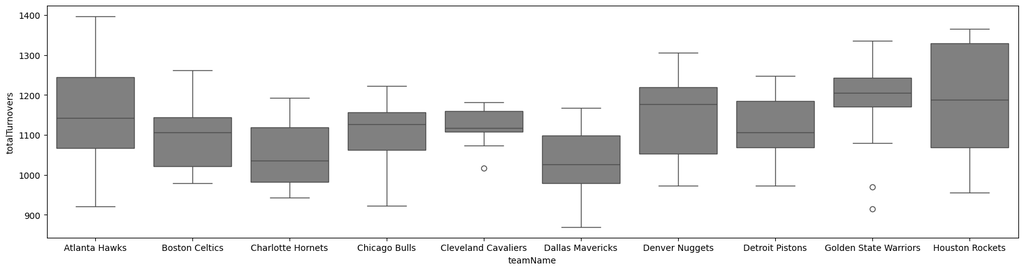

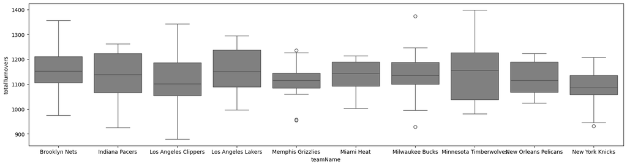

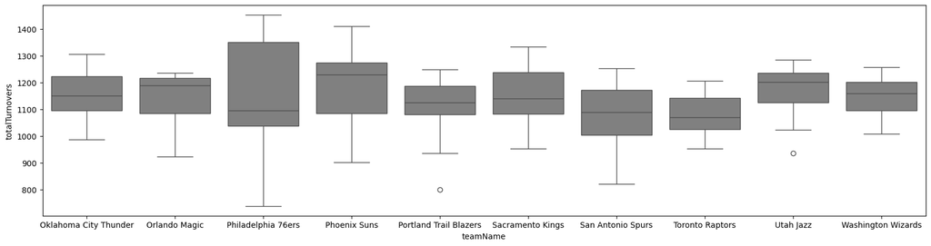

```python
plot_boxplot("totalTurnovers",regular_season_team_summary_stats_1)
plot_boxplot("totalTurnovers",regular_season_team_summary_stats_2)
plot_boxplot("totalTurnovers",regular_season_team_summary_stats_3)
```

For turnovers, Golden State Warriors was selected as the higher-performing team while Dallas Mavericks was selected as the lower-performing team. As with fouls, turnovers is also considered a negative metric in basketball. Therefore, having fewer turnovers is considered a positive attribute in basketball.

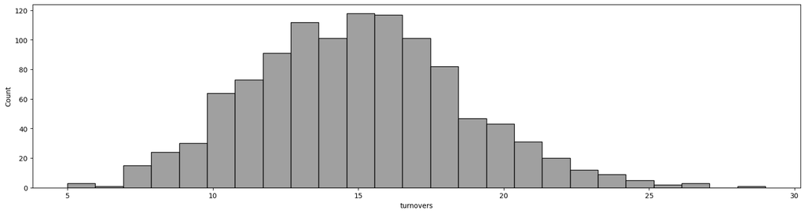

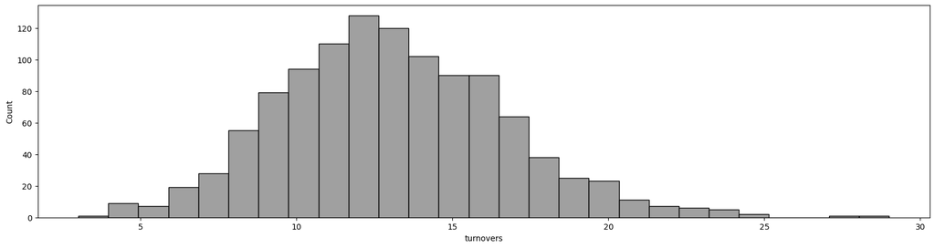

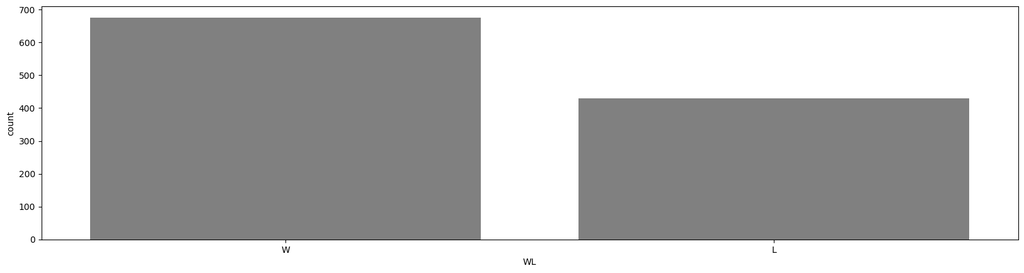

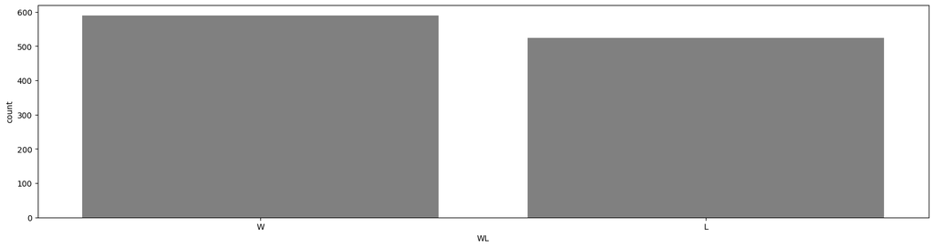

```python
dal_regular_season_totals = regular_season_totals[regular_season_totals["teamName"]=="Dallas Mavericks"]

plot_histogram("turnovers",gsw_regular_season_totals)
plot_histogram("turnovers",dal_regular_season_totals)
plot_barchart("WL",gsw_regular_season_totals)
plot_barchart("WL",dal_regular_season_totals)
```

Despite having more turnovers, the Golden State Warriors won more games than the Dallas Mavericks. Same with fouls, the confidence interval analysis will be focused on the mean difference in turnovers when the Dallas Mavericks beat the Golden State Warriors, as the relationship of having favourable values of turnovers with winning is being analyzed.

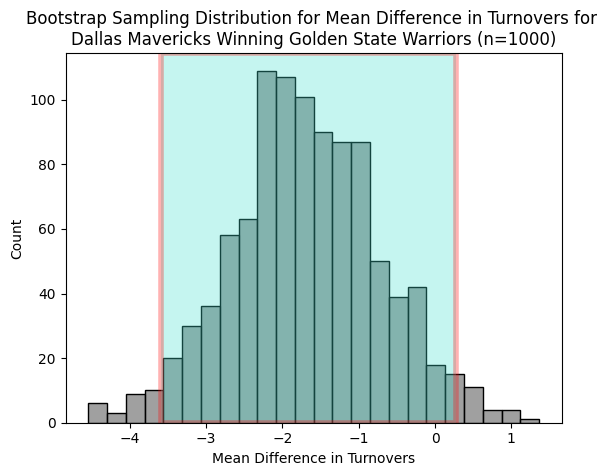

```
[-3.5920454545454543, 0.2727272727272727]
```

```python
np.random.seed(100)

combined_games_regular_season["diffTurnovers"] = combined_games_regular_season["turnovers_x"] - combined_games_regular_season["turnovers_y"]
combined_games_play_offs["diffTurnovers"] = combined_games_play_offs["turnovers_x"] - combined_games_play_offs["turnovers_y"]

gsw_dal_games = combined_games_regular_season[(combined_games_regular_season["teamName_x"]=="Dallas Mavericks") & (combined_games_regular_season["teamName_y"]=="Golden State Warriors")]

gsw_dal_blocks_bootstrap_distribution = bootstrap_distribution("diffTurnovers",gsw_dal_games)

gsw_dal_blocks_percentile_confidence_interval = confidence_interval(gsw_dal_blocks_bootstrap_distribution)

plt.xlabel("Mean Difference in Turnovers")
plt.title("Bootstrap Sampling Distribution for Mean Difference in Turnovers for \nDallas Mavericks Winning Golden State Warriors (n=1000)")
gsw_dal_blocks_confidence_interval = visualize_confidence_interval(gsw_dal_blocks_bootstrap_distribution,gsw_dal_blocks_percentile_confidence_interval)
print(gsw_dal_blocks_percentile_confidence_interval)
```

The 95% confidence interval includes mostly negative values and has an upper bound close to 0. As such, the data may suggest that having fewer turnovers is associated with winning.

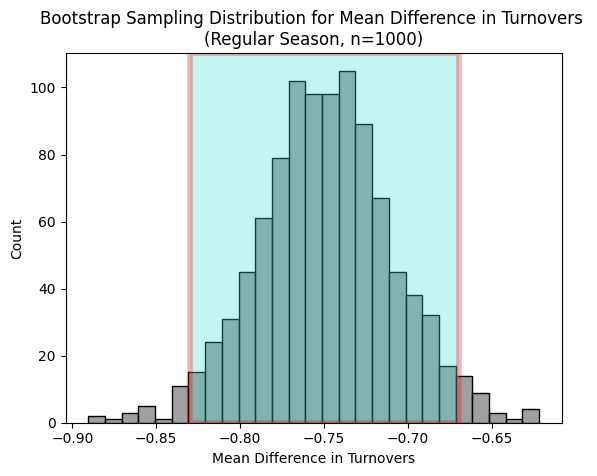

```
[-0.8297679793492616, -0.6694636210829632]
```

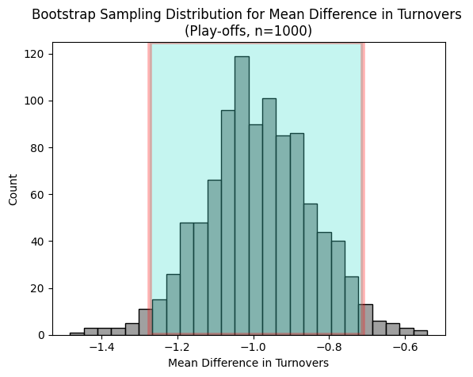

```
[-1.2718412302576891, -0.7115544472152951]
```

```python
np.random.seed(100)

turnovers_regular_season_bootstrap_distribution = bootstrap_distribution("diffTurnovers",combined_games_regular_season)

turnovers_regular_season_percentile_confidence_interval = confidence_interval(turnovers_regular_season_bootstrap_distribution)

plt.xlabel("Mean Difference in Turnovers")
plt.title("Bootstrap Sampling Distribution for Mean Difference in Turnovers \n(Regular Season, n=1000)")
turnovers_regular_season_confidence_interval = visualize_confidence_interval(turnovers_regular_season_bootstrap_distribution,turnovers_regular_season_percentile_confidence_interval)
print(turnovers_regular_season_percentile_confidence_interval)

turnovers_play_offs_bootstrap_distribution = bootstrap_distribution("diffTurnovers",combined_games_play_offs)

turnovers_play_offs_percentile_confidence_interval = confidence_interval(turnovers_play_offs_bootstrap_distribution)

plt.xlabel("Mean Difference in Turnovers")
plt.title("Bootstrap Sampling Distribution for Mean Difference in Turnovers \n(Play-offs, n=1000)")
turnovers_play_offs_confidence_interval = visualize_confidence_interval(turnovers_play_offs_bootstrap_distribution,turnovers_play_offs_percentile_confidence_interval)
print(turnovers_play_offs_percentile_confidence_interval)
```

Though the 95% confidence intervals range negative values, the magnitudes are mostly below 1, thus showing minimal association between committing fewer turnovers and winning. As the entire sample is larger and produces a more precise interval, the results here are more reliable.

#### Field Goal Attempts

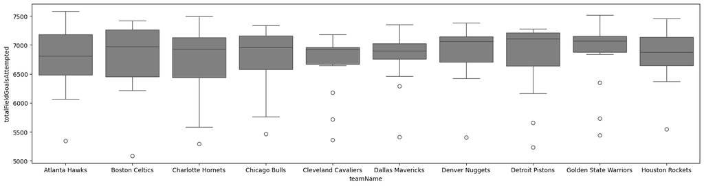

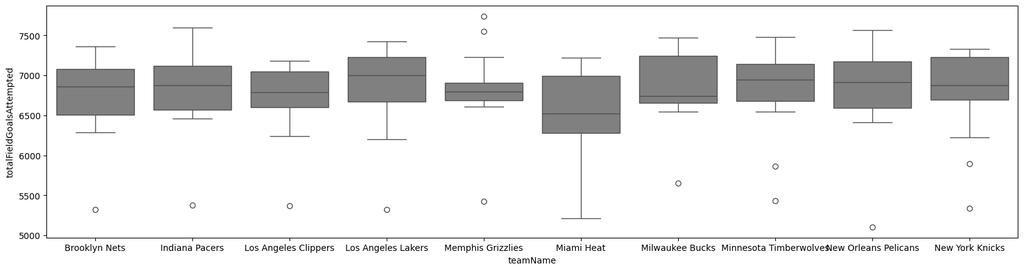

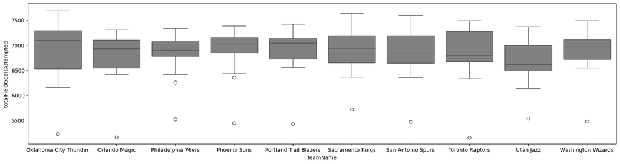

```python
plot_boxplot("totalFieldGoalsAttempted",regular_season_team_summary_stats_1)
plot_boxplot("totalFieldGoalsAttempted",regular_season_team_summary_stats_2)
plot_boxplot("totalFieldGoalsAttempted",regular_season_team_summary_stats_3)
```

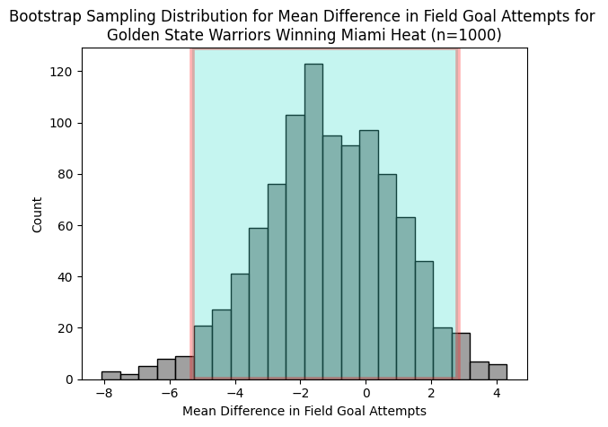

```
[-5.3140625, 2.8125]
```

```python
np.random.seed(100)

combined_games_regular_season["diffFieldGoalAttempts"] = combined_games_regular_season["fieldGoalsAttempted_x"] - combined_games_regular_season["fieldGoalsAttempted_y"]

combined_games_play_offs["diffFieldGoalAttempts"] = combined_games_play_offs["fieldGoalsAttempted_x"] - combined_games_play_offs["fieldGoalsAttempted_y"]

gsw_mia_games = combined_games_regular_season[(combined_games_regular_season["teamName_x"]=="Golden State Warriors") & (combined_games_regular_season["teamName_y"]=="Miami Heat")]

gsw_mia_field_goal_attempts_bootstrap_distribution = bootstrap_distribution("diffFieldGoalAttempts",gsw_mia_games)

gsw_mia_field_goal_attempts_percentile_confidence_interval = confidence_interval(gsw_mia_field_goal_attempts_bootstrap_distribution)

plt.xlabel("Mean Difference in Field Goal Attempts")
plt.title("Bootstrap Sampling Distribution for Mean Difference in Field Goal Attempts for \nGolden State Warriors Winning Miami Heat (n=1000)")
gsw_mia_field_goal_attempts_confidence_interval = visualize_confidence_interval(gsw_mia_field_goal_attempts_bootstrap_distribution,gsw_mia_field_goal_attempts_percentile_confidence_interval)
print(gsw_mia_field_goal_attempts_percentile_confidence_interval)
```

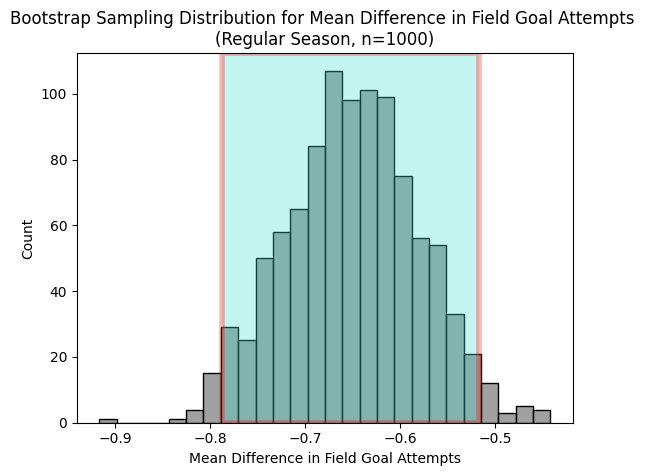

```
[-0.7874414695641734, -0.5167156921599232]
```

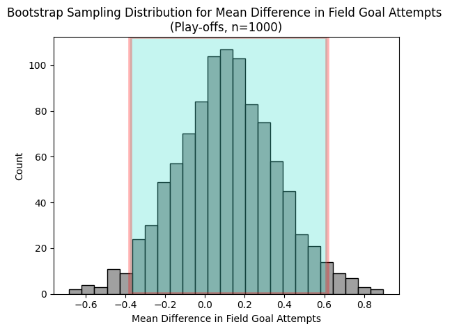

```
[-0.37578969243557775, 0.6169576059850372]
```

```python
np.random.seed(100)

field_goal_attempts_regular_season_bootstrap_distribution = bootstrap_distribution("diffFieldGoalAttempts",combined_games_regular_season)

field_goal_attempts_regular_season_percentile_confidence_interval = confidence_interval(field_goal_attempts_regular_season_bootstrap_distribution)

plt.xlabel("Mean Difference in Field Goal Attempts")
plt.title("Bootstrap Sampling Distribution for Mean Difference in Field Goal Attempts \n(Regular Season, n=1000)")
field_goal_attempts_regular_season_confidence_interval = visualize_confidence_interval(field_goal_attempts_regular_season_bootstrap_distribution,field_goal_attempts_regular_season_percentile_confidence_interval)
print(field_goal_attempts_regular_season_percentile_confidence_interval)

field_goal_attempts_play_offs_bootstrap_distribution = bootstrap_distribution("diffFieldGoalAttempts",combined_games_play_offs)

field_goal_attempts_play_offs_percentile_confidence_interval = confidence_interval(field_goal_attempts_play_offs_bootstrap_distribution)

plt.xlabel("Mean Difference in Field Goal Attempts")
plt.title("Bootstrap Sampling Distribution for Mean Difference in Field Goal Attempts \n(Play-offs, n=1000)")
field_goal_attempts_play_offs_confidence_interval = visualize_confidence_interval(field_goal_attempts_play_offs_bootstrap_distribution,field_goal_attempts_play_offs_percentile_confidence_interval)
print(field_goal_attempts_play_offs_percentile_confidence_interval)
```

As previously predicted, using the regular season and play-offs samples suggest that there may be minimal association between attempting more field goals and winning games.